# Linear Regression Code Sheet - NextGen AI Lecture 1

# **YOU CANNOT EDIT THIS NOTEBOOK. Goto colab.research.google.com and make a new python 3 file. Copy and paste the blocks of code to begin!**

**you can run blocks of code by pressing shift+enter**

Today, we explored the concept of linear regression. Using your conceptual understanding of the idea, this worksheet will aim to guide you through coding linear regression from scratch in python. To remind you, the ultimate goal is to take a dataset that has a linear relationship and try to form a linear regression that can effectively make a prediction. For example, if we have a dataset that tries to correlate crime rate of town to house price, our linear regression will be able to make a prediction of how expensive a house might be given its crime rate. We can form the linear regression model by finding the optimal slope (m) and y-intercept (b) values that minimize the residuals, or error (the difference between the true and predicted values obtained from our regression).

Importing Our Necessary Data from the Boston Housing Dataset. We will be correlating average rooms per dwelling versus house price.

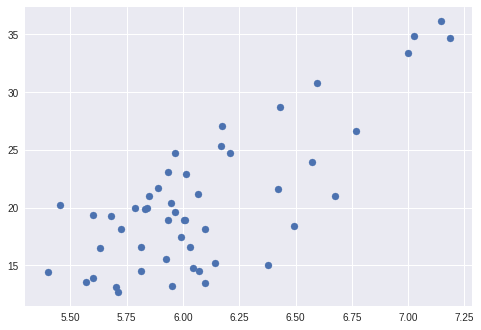

```python
import matplotlib.pyplot as plt
from sklearn import datasets
import pandas as pd

boston = datasets.load_boston()

# If you want to read more about the dataset we are using uncomment this function.
# print(boston.DESCR)

bs = pd.DataFrame(boston.data)
bs.columns = boston.feature_names
bs['PRICE'] = boston.target
X = bs['RM'] #getting our X-values (what we are using to predict)
Y = bs['PRICE'] #getting our Y-values (what we are predicting)
X = X[:50]
Y = Y[:50]
plt.scatter(X,Y)
```

Writing Our Error Function. Look at the worksheet for more explanation.

```python
def error(m, b, X, Y):
  """ Calculate the average of the residuals of a line defined
    by a slope and intercept from the X, Y values.

    Make sure to remember that each residual is the distance
    to the line vertically squared(use your math skills!)

    We will use the value this function returns as the error of
    slope and y-intercept.

    Important CS Concepts to Use:
        1. loops
        2. array handling
    If you are confused about how to do these things in python,
    refer to the python cheatsheet on our website or ask for help!"""

print("Error at m=0, b=0: " + str(error(0,0, X, Y)))
```

[output not shown]

Writing a few helper functions.

```python
def mslope(m_current, b_current, X, Y):
    """ use the formula to write this function """

def bslope(m_current, b_current, X, Y):
    """ use the formula to write this function """


def calculateNewM(m_slope, m_current, learning_rate):

    """ using the important patterns regarding slope
    and how we want it to affect our m value (pg 4),
    write a function that returns a new m_current value.

    The learning rate determines how much you want to shift
    our m_value in proportion to m_slope.
    (For example, if our m_slope was one and our learning_rate
    was 0.5, we would shift m_current by .5) """


def calculateNewB(b_slope, b_current, learning_rate):

    """ using the important patterns regarding slope
    and how we want it to affect our b- value (pg 4),
    write a function that returns a new m_current value.

    The learning rate determines how much you want to shift
    our b_value in proportion to b_slope.
    (For example, if our b_slope was one and our learning_rate
    was 0.5, we would shift b_current by .5) """
```

Writing Our Linear Regression Function!

```python
def linear_regression(X, Y, m_current, b_current, epochs, learning_rate):

  """ Follow the directions in the worksheet """


  return m_current, b_current
```

Running it

```python
slope, intercept = linear_regression(X, Y, 0, 0, 100000, 1e-2)
print(slope,intercept)
```

[output not shown]

Graphing Our Regression!

```python
import numpy as np

f = lambda x: slope*x + intercept
x = np.array([0,10])

plt.plot(x,f(x),lw=2.5, c="k",label="fit line between 0 and 100")
plt.scatter(X,Y)
plt.ylim(4,9)
plt.ylim(0,60)
```

[output not shown]